# Parkinson’s disease

Mahsa Raeiati Banadkooki

8/14/2021

# Test Code

This code just was written to analyize the Parkinson’s disease as a sample code. It was used some visualization analysis. Also the decision tree and support vector machine were used for classifying the dataset.

## The Data

https://wiki.socr.umich.edu/index.php/SOCR_Data_PD_BiomedBigMetadata

This case-study uses simulation to examine associations between clinical, demographic, imaging and genetics variables for Parkinson’s disease. This is an example of Big Data for investigating important neurodegenerative disorders.

The dataset contains:

ID: Case subject identifier

Imaging Biomarkers: ComputeArea = surface area of 3D brain region of interest, Volume= the 3D volume/size of the region of interest, region name is encoded in morphometry measure name (e.g., L_putamen_ComputeArea represents the left putamen surface area): L_caudate_ComputeArea, L_caudate_Volume, R_caudate_ComputeArea, R_caudate_Volume, L_putamen_ComputeArea, L_putamen_Volume, R_putamen_ComputeArea, R_putamen_Volume, L_hippocampus_ComputeArea, L_hippocampus_Volume, R_hippocampus_ComputeArea, R_hippocampus_Volume, cerebellum_ComputeArea, cerebellum_Volume, L_lingual_gyrus_ComputeArea, L_lingual_gyrus_Volume, R_lingual_gyrus_ComputeArea, R_lingual_gyrus_Volume, L_fusiform_gyrus_ComputeArea, L_fusiform_gyrus_Volume, R_fusiform_gyrus_ComputeArea, R_fusiform_gyrus_Volume

Demographics variables: Sex, Weight, Age

Diagnosis: Dx, PD=Parkinson’s, HC=Healthy Control, SWEDD = (tremor associated clinical parkinsonism features) scans without evidence of dopaminergic deficit

Genetics: chr12_rs34637584_GT, chr17_rs11868035_GT

Clinical: UPDRS_part_I, UPDRS_part_II, UPDRS_part_III (Movement Disorder Society-Sponsored Revision of the Unified. Parkinson’s Disease Rating Scale (MDS-UPDRS)), (Normal=0)

Time: VisitTime: four time-points (baseline (0), 6, 12, and 18 month follow-ups).

```r
library(xml2)
library(rvest)
url_data <- read_html("http://wiki.socr.umich.edu/index.php/SOCR_Data_PD_BiomedBigMetadata")
data <- html_table(html_nodes(url_data, "table")[[1]])
data <- data[, -c(1,33)] # Remove the ID and Time
library(psych)
describe(data)
```

```
##                              vars    n     mean     sd  median  trimmed    mad
## L_caudate_ComputeArea           1 1128   600.39  26.42   600.0   600.63  27.43
## L_caudate_Volume                2 1128   800.33  27.12   800.0   800.50  26.69
## R_caudate_ComputeArea           3 1128   894.54  29.95   897.0   895.57  29.65
## R_caudate_Volume                4 1128  1001.16  32.56   998.0  1000.77  32.62
## L_putamen_ComputeArea           5 1128   898.93  31.05   897.5   898.40  31.13
## L_putamen_Volume                6 1128  1400.40  37.78  1400.0  1400.89  38.55
## R_putamen_ComputeArea           7 1128  1299.71  32.41  1302.0  1299.68  31.88
## R_putamen_Volume                8 1128  3000.30  58.14  3000.5  2999.92  58.56
## L_hippocampus_ComputeArea       9 1128  1302.09  37.49  1300.0  1300.78  35.58
## L_hippocampus_Volume           10 1128  3198.50  53.32  3199.5  3197.70  47.44
## R_hippocampus_ComputeArea      11 1128  1504.35  36.16  1504.5  1504.28  37.81
## R_hippocampus_Volume           12 1128  3799.29  62.61  3801.5  3798.86  54.11
## cerebellum_ComputeArea         13 1128 16699.60 126.68 16699.0 16699.51 126.02
## cerebellum_Volume              14 1128 14001.61 117.94 13995.5 14001.79 108.23
## L_lingual_gyrus_ComputeArea    15 1128  3300.20  57.70  3299.0  3299.29  51.89
## L_lingual_gyrus_Volume         16 1128 11010.39 111.11 11007.0 11008.59  99.33
## R_lingual_gyrus_ComputeArea    17 1128  3296.32  58.91  3294.0  3296.30  56.34
## R_lingual_gyrus_Volume         18 1128 12007.65 106.05 12001.0 12007.35 105.26
## L_fusiform_gyrus_ComputeArea   19 1128  3598.07  57.92  3594.5  3596.92  60.79
## L_fusiform_gyrus_Volume        20 1128 11011.18 110.89 11016.0 11013.34 104.52
## R_fusiform_gyrus_ComputeArea   21 1128  3298.63  58.05  3296.0  3298.44  53.37
## R_fusiform_gyrus_Volume        22 1128  9995.76  93.55  9993.5  9994.24  96.37
## Sex                            23 1128     0.59   0.49     1.0     0.61   0.00
## Weight                         24 1128    78.45  10.20    78.5    78.12   9.64
## Age                            25 1128    60.64  10.14    61.0    60.66  10.38
## Dx*                            26 1128     1.94   0.80     2.0     1.92   1.48
## chr12_rs34637584_GT            27 1128     0.54   0.50     1.0     0.55   0.00
## chr17_rs11868035_GT            28 1128     0.42   0.49     0.0     0.40   0.00
## UPDRS_part_I                   29 1128     0.77   0.73     1.0     0.72   1.48
## UPDRS_part_II                  30 1128     8.88   5.09     9.0     8.67   5.93
## UPDRS_part_III                 31 1128    13.02   7.80    13.0    12.74   8.90
##                                min   max range  skew kurtosis   se
## L_caudate_ComputeArea          525   667   142 -0.09    -0.31 0.79
## L_caudate_Volume               719   890   171  0.01     0.22 0.81
## R_caudate_ComputeArea          795   977   182 -0.32     0.18 0.89
## R_caudate_Volume               916  1094   178  0.10    -0.30 0.97
## L_putamen_ComputeArea          815  1003   188  0.19     0.19 0.92
## L_putamen_Volume              1298  1507   209 -0.14    -0.19 1.12
## R_putamen_ComputeArea         1198  1392   194 -0.04    -0.06 0.96
```

[output cut: 9 more lines]

```
## R_lingual_gyrus_ComputeArea   3135  3490   355  0.06     0.29 1.75
## R_lingual_gyrus_Volume       11679 12324   645  0.01    -0.11 3.16
## L_fusiform_gyrus_ComputeArea  3446  3763   317  0.15    -0.25 1.72
## L_fusiform_gyrus_Volume      10682 11394   712 -0.10     0.25 3.30
## R_fusiform_gyrus_ComputeArea  3094  3443   349 -0.09     0.30 1.73
## R_fusiform_gyrus_Volume       9736 10235   499  0.11    -0.16 2.79
## Sex                              0     1     1 -0.35    -1.88 0.01
## Weight                          51   109    58  0.22    -0.04 0.30
## Age                             31    87    56 -0.04    -0.35 0.30
## Dx*                              1     3     2  0.12    -1.43 0.02
## chr12_rs34637584_GT              0     1     1 -0.16    -1.98 0.01
## chr17_rs11868035_GT              0     1     1  0.33    -1.89 0.01
## UPDRS_part_I                     0     2     2  0.38    -1.07 0.02
## UPDRS_part_II                    1    20    19  0.21    -0.89 0.15
## UPDRS_part_III                   1    30    29  0.23    -0.86 0.23
```

# Load the libraries

```r
library(ggplot2)
library(reshape2)
library(viridis)
library(GGally)
library(rpart.plot)
library(rpart)
library(e1071)
set.seed(1234)
```

# Data Visualization

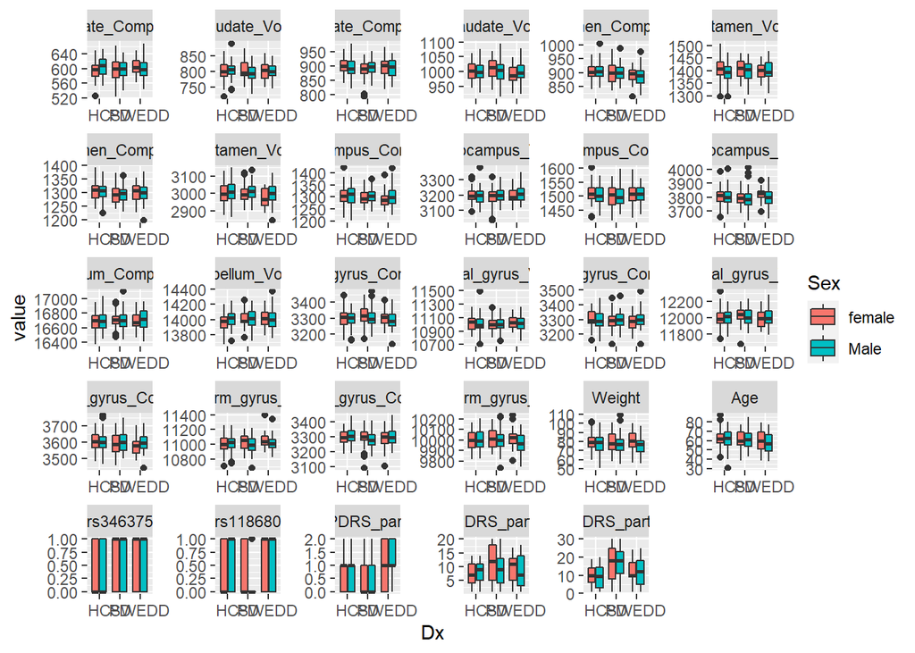

# Create the sample boxplot for “weight” variable on two different grouping variables; “Age” on x-axis and “Sex” as fill color (legend variable).

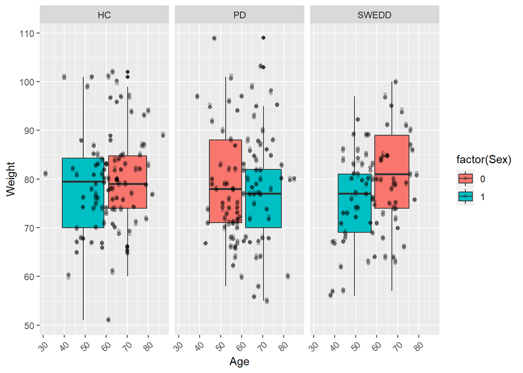

```r
gplot <- ggplot(data, aes( x= Age, y=Weight, fill=factor(Sex))) +
         geom_boxplot() +
         geom_jitter(width=0.1,alpha=0.2) +
         facet_wrap(~Dx) +
         theme(axis.text.x = element_text(angle = 45, hjust = 1))
print(gplot)
```

# Correlation plot for dataset

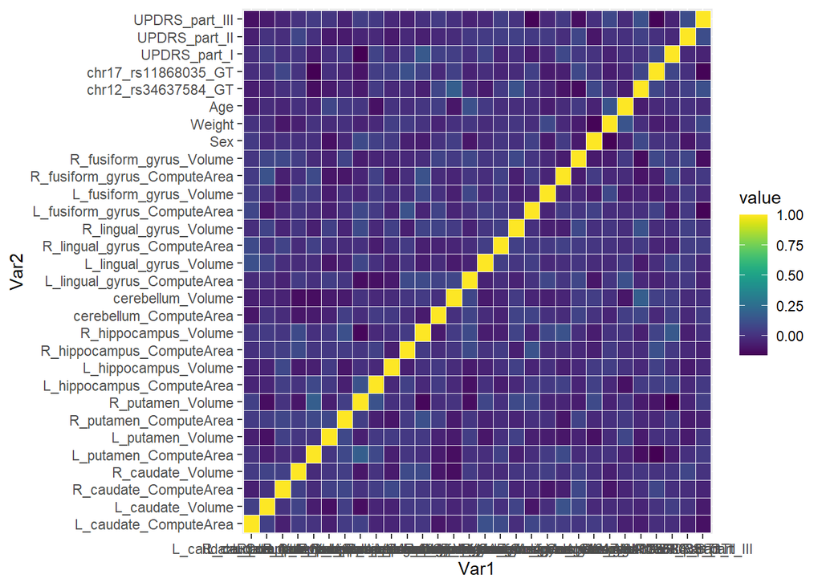

```r
cormat <- round(cor(as.matrix(data[, -26])),2) # Remove the Dx, it is categorical data
melted_cor_data <- melt(cormat)
ggplot(data = melted_cor_data, aes(x=Var1, y=Var2, fill=value)) +
    geom_tile(color="white", size=0.1)+
    scale_fill_viridis(discrete=FALSE)
```

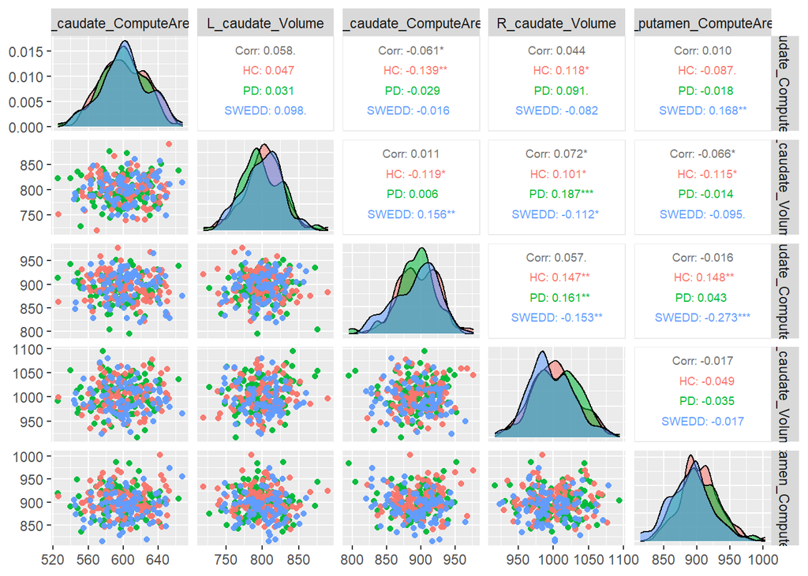

```r
ggpairs(data, columns = 1:5, aes(color = Dx, alpha = 0.5),
        upper = list(continuous = wrap("cor", size = 2.5)))
```

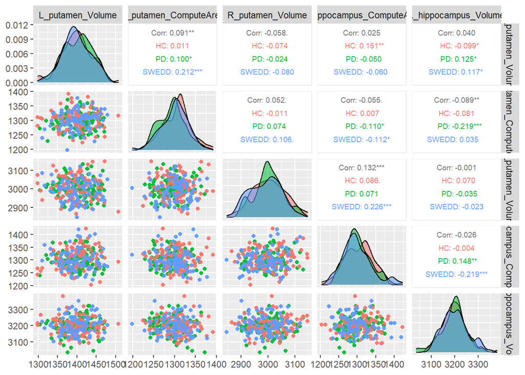

```r
ggpairs(data, columns = 6:10, aes(color = Dx, alpha = 0.5),
       upper = list(continuous = wrap("cor", size = 2.5)))
```

# Decision Tree

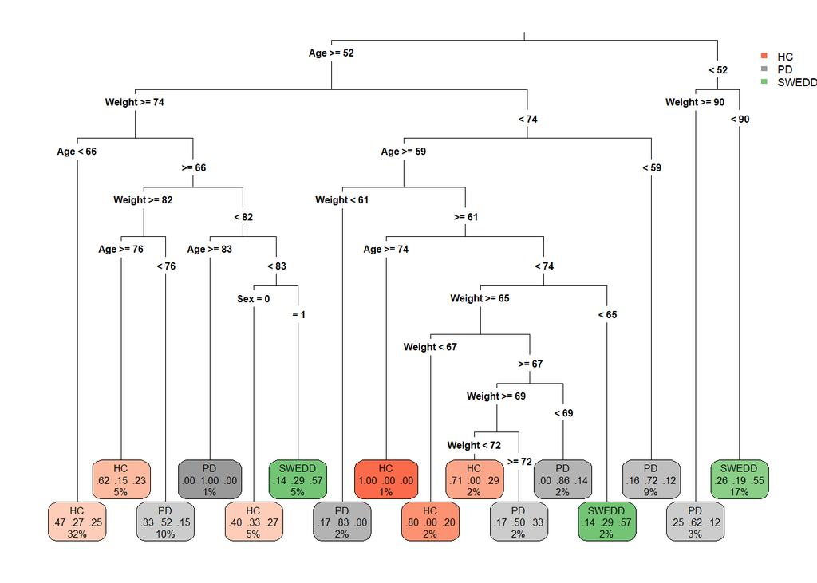

```r
data.tree <- rpart(Dx~Age + Sex+ Weight, data = data)

rpart.plot(data.tree, fallen.leaves = T,  digit = 2,
           type = 3,  cex=0.5, legend.x = 0.98, legend.y = 1)
```

# Support Vector Machine

SVM was used for classifying the data into three different groups with 69% of accuracy.

```r
# Normalized the Data
set.seed(299)
normalize <- function(x) { return ((x - min(x)) / (max(x) - min(x)))}
data_norm <- as.data.frame(lapply(data[, -26], normalize))
data_norm <- data.frame(data_norm, "Dx" = data$Dx)

# Seprate the 70 % of data for Train data and 30% of data for Test
sub_sample <- sample(nrow(data_norm), floor(nrow(data_norm)*0.70))
data_train <- data_norm[sub_sample, ]
data_test <- data_norm[-sub_sample, ]

# Support vector Machine for classify data into three class

svm_model <- svm(Dx~., data = data_train, kernel="linear")
table(data_test$Dx,  predict(svm_model, data_test))
```

```
##
##         HC PD SWEDD
##   HC    84 18    17
##   PD     8 99    13
##   SWEDD 24 25    51
```

```r
result <- predict(svm_model, data_test)==data_test$Dx
prop.table(table(result))
```

```
## result
##     FALSE      TRUE
## 0.3097345 0.6902655
```